# Basic R script

### Basics

A vector is the most common and basic data type in R, and is pretty much the workhorse of R. A vector is composed by a series of values, which can be either numbers or characters. We can assign a series of values to a vector using the `c()' function. For example we can create a vector of weights and assign it to a new object`y1’:

```r
a <- 0 #numeric variable
y1 <- c(1, 2, 3, 4, 5) #arbitrary vector of numbers
y2 <- 1:9 #a sequence of numbers
hello <- c("Hello", "World") #vector of strings
```

If we arrange data elements of a vector in a two-dimensional rectangular layout we have a matrix. To construct a matrix, we use a function conveniently called `matrix()’.

```r
mat1 = matrix(c(8,4,5,6),nrow = 2, ncol = 2,byrow = TRUE)
mat2 = matrix(1:4,nrow = 2, ncol = 2,byrow = TRUE)
```

By using `*’, we multiply two matrix element by element:

```r
print(mat1 * mat2)
```

```
##      [,1] [,2]
## [1,]    8    8
## [2,]   15   24
```

The matrix product operator is `%*%’:

```r
print(mat1 %*% mat2)
```

```
##      [,1] [,2]
## [1,]   20   32
## [2,]   23   34
```

You have seen the function c() that can be used to combine objects. In general, all function calls look the same: a function name is always followed by round parentheses. Sometimes, the parentheses include arguments.

We generate a sequence of numbers from 1 to 5, where the steplength is 2.

```r
z <- seq(from = 1, to = 5, by = 2)
mean(z)
```

```
## [1] 3
```

### Define functions

The functions can be defined using the basic format. The function can take 0 /1/ many arguement. Here is an example of the 2 arguement functions.

```r
product <- function(x,y)
{
  x * y
}
product(1,3)
```

```
## [1] 3
```

```r
product(mat1,mat2)
```

```
##      [,1] [,2]
## [1,]    8    8
## [2,]   15   24
```

### Set seed

```r
set.seed(1)
print(rnorm(10))
```

```
##  [1] -0.6264538  0.1836433 -0.8356286  1.5952808  0.3295078 -0.8204684
##  [7]  0.4874291  0.7383247  0.5757814 -0.3053884
```

```r
print(rnorm(10))
```

```
##  [1]  1.51178117  0.38984324 -0.62124058 -2.21469989  1.12493092 -0.04493361
##  [7] -0.01619026  0.94383621  0.82122120  0.59390132
```

```r
set.seed(1)
print(rnorm(10))
```

```
##  [1] -0.6264538  0.1836433 -0.8356286  1.5952808  0.3295078 -0.8204684
##  [7]  0.4874291  0.7383247  0.5757814 -0.3053884
```

### Random sampling

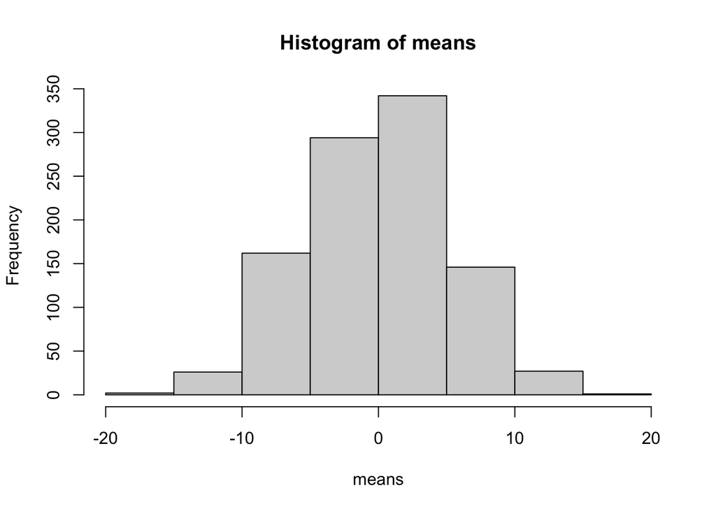

```r
nreps = 1000
sample_size = 30
sample <- replicate(nreps,rnorm(sample_size))
means <- colSums(sample)
hist(means)
```

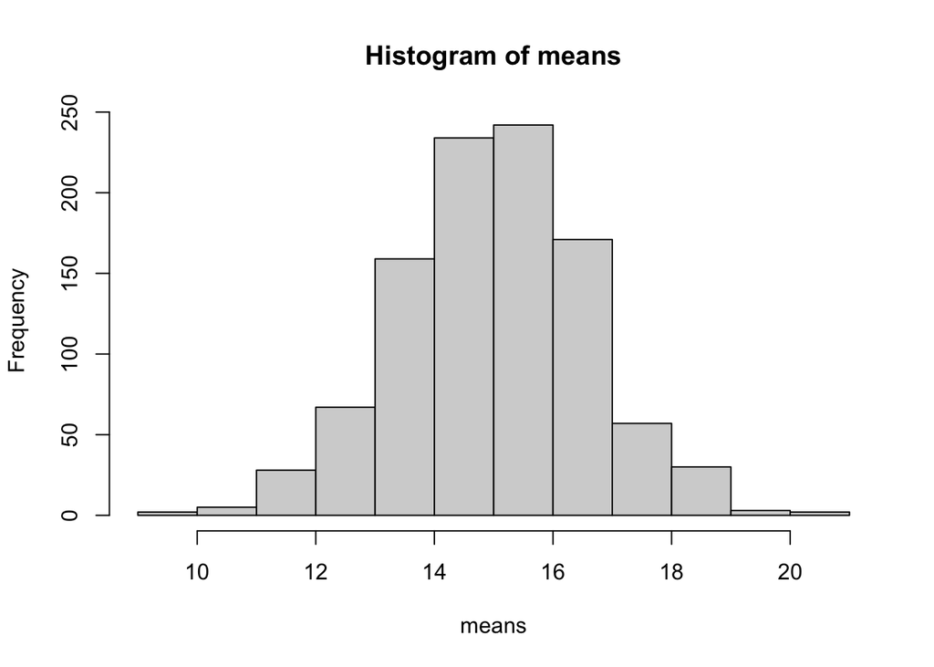

```r
nreps = 1000
sample_size = 30
sample <- replicate(nreps,runif(sample_size))
means <- colSums(sample)
hist(means)
```

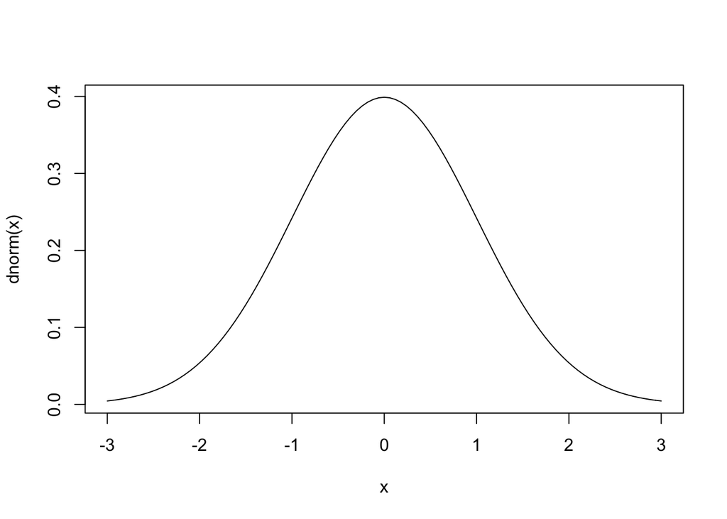

```r
curve(dnorm,from=-3,to=3)
```

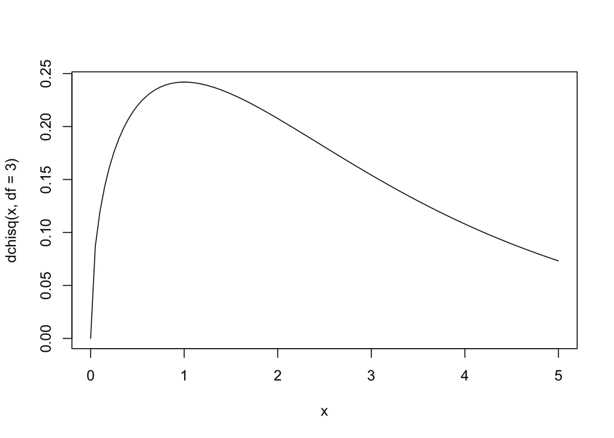

```r
curve(dchisq(x, df = 3), from=0,to=5)
```